# Risk Factor Analysis

## Outcome Variable

**Outcome Variable:** whz

## Predictor Variables

**Intervention Variable:** exclfeed3

**Adjustment Set:**

- arm
- sex
- W_mage
- meducyrs
- feducyrs
- hhwealth_quart
- hfoodsec
- W_mhtcm
- vagbrth
- W_gagebrth
- W_birthwt
- W_birthlen
- W_nrooms
- W_nchldlt5
- month
- brthmon
- W_parity
- impfloor
- impsan
- safeh20
- delta_W_mage
- delta_meducyrs
- delta_feducyrs
- delta_hhwealth_quart
- delta_hfoodsec
- delta_W_mhtcm
- delta_vagbrth
- delta_W_gagebrth
- delta_W_birthwt
- delta_W_birthlen
- delta_W_nrooms
- delta_W_nchldlt5
- delta_month
- delta_brthmon
- delta_W_parity
- delta_impfloor
- delta_impsan
- delta_safeh20

## Stratifying Variables

The analysis was stratified on these variable(s):

- agecat
- studyid
- country

## Data Summary

| agecat | studyid | country | exclfeed3 | n_cell | n |
| --- | --- | --- | --- | --- | --- |
| Birth | ki0047075b-MAL-ED | BANGLADESH | 1 | 164 | 227 |
| Birth | ki0047075b-MAL-ED | BANGLADESH | 0 | 63 | 227 |
| Birth | ki0047075b-MAL-ED | BRAZIL | 1 | 65 | 177 |
| Birth | ki0047075b-MAL-ED | BRAZIL | 0 | 112 | 177 |
| Birth | ki0047075b-MAL-ED | INDIA | 1 | 121 | 193 |
| Birth | ki0047075b-MAL-ED | INDIA | 0 | 72 | 193 |
| Birth | ki0047075b-MAL-ED | NEPAL | 1 | 60 | 166 |
| Birth | ki0047075b-MAL-ED | NEPAL | 0 | 106 | 166 |
| Birth | ki0047075b-MAL-ED | PERU | 1 | 64 | 265 |
| Birth | ki0047075b-MAL-ED | PERU | 0 | 201 | 265 |
| Birth | ki0047075b-MAL-ED | SOUTH AFRICA | 1 | 32 | 231 |
| Birth | ki0047075b-MAL-ED | SOUTH AFRICA | 0 | 199 | 231 |
| Birth | ki0047075b-MAL-ED | TANZANIA, UNITED REPUBLIC OF | 1 | 38 | 114 |
| Birth | ki0047075b-MAL-ED | TANZANIA, UNITED REPUBLIC OF | 0 | 76 | 114 |
| Birth | ki1000108-CMC-V-BCS-2002 | INDIA | 1 | 4 | 4 |
| Birth | ki1000108-CMC-V-BCS-2002 | INDIA | 0 | 0 | 4 |
| Birth | ki1000108-IRC | INDIA | 1 | 0 | 9 |
| Birth | ki1000108-IRC | INDIA | 0 | 9 | 9 |
| Birth | ki1000109-EE | PAKISTAN | 1 | 1 | 1 |
| Birth | ki1000109-EE | PAKISTAN | 0 | 0 | 1 |
| Birth | ki1000304b-SAS-CompFeed | INDIA | 1 | 45 | 47 |
| Birth | ki1000304b-SAS-CompFeed | INDIA | 0 | 2 | 47 |
| Birth | ki1101329-Keneba | GAMBIA | 1 | 1150 | 1305 |
| Birth | ki1101329-Keneba | GAMBIA | 0 | 155 | 1305 |
| Birth | kiGH5241-JiVitA-3 | BANGLADESH | 1 | 13731 | 15136 |
| Birth | kiGH5241-JiVitA-3 | BANGLADESH | 0 | 1405 | 15136 |
| Birth | kiGH5241-JiVitA-4 | BANGLADESH | 1 | 28 | 31 |
| Birth | kiGH5241-JiVitA-4 | BANGLADESH | 0 | 3 | 31 |
| 6 months | ki0047075b-MAL-ED | BANGLADESH | 1 | 172 | 237 |
| 6 months | ki0047075b-MAL-ED | BANGLADESH | 0 | 65 | 237 |

[output cut: 58 more lines]

The following strata were considered:

- agecat: 24 months, studyid: ki0047075b-MAL-ED, country: BANGLADESH
- agecat: 24 months, studyid: ki0047075b-MAL-ED, country: BRAZIL
- agecat: 24 months, studyid: ki0047075b-MAL-ED, country: INDIA
- agecat: 24 months, studyid: ki0047075b-MAL-ED, country: NEPAL
- agecat: 24 months, studyid: ki0047075b-MAL-ED, country: PERU
- agecat: 24 months, studyid: ki0047075b-MAL-ED, country: SOUTH AFRICA
- agecat: 24 months, studyid: ki0047075b-MAL-ED, country: TANZANIA, UNITED REPUBLIC OF
- agecat: 24 months, studyid: ki1000108-CMC-V-BCS-2002, country: INDIA
- agecat: 24 months, studyid: ki1000108-IRC, country: INDIA
- agecat: 24 months, studyid: ki1017093b-PROVIDE, country: BANGLADESH
- agecat: 24 months, studyid: ki1101329-Keneba, country: GAMBIA
- agecat: 24 months, studyid: ki1113344-GMS-Nepal, country: NEPAL
- agecat: 24 months, studyid: kiGH5241-JiVitA-3, country: BANGLADESH
- agecat: 24 months, studyid: kiGH5241-JiVitA-4, country: BANGLADESH
- agecat: 6 months, studyid: ki0047075b-MAL-ED, country: BANGLADESH
- agecat: 6 months, studyid: ki0047075b-MAL-ED, country: BRAZIL
- agecat: 6 months, studyid: ki0047075b-MAL-ED, country: INDIA
- agecat: 6 months, studyid: ki0047075b-MAL-ED, country: NEPAL
- agecat: 6 months, studyid: ki0047075b-MAL-ED, country: PERU
- agecat: 6 months, studyid: ki0047075b-MAL-ED, country: SOUTH AFRICA
- agecat: 6 months, studyid: ki0047075b-MAL-ED, country: TANZANIA, UNITED REPUBLIC OF
- agecat: 6 months, studyid: ki1000108-CMC-V-BCS-2002, country: INDIA
- agecat: 6 months, studyid: ki1000108-IRC, country: INDIA
- agecat: 6 months, studyid: ki1000109-EE, country: PAKISTAN
- agecat: 6 months, studyid: ki1000304b-SAS-CompFeed, country: INDIA
- agecat: 6 months, studyid: ki1017093b-PROVIDE, country: BANGLADESH
- agecat: 6 months, studyid: ki1101329-Keneba, country: GAMBIA
- agecat: 6 months, studyid: ki1113344-GMS-Nepal, country: NEPAL
- agecat: 6 months, studyid: kiGH5241-JiVitA-3, country: BANGLADESH
- agecat: 6 months, studyid: kiGH5241-JiVitA-4, country: BANGLADESH
- agecat: Birth, studyid: ki0047075b-MAL-ED, country: BANGLADESH
- agecat: Birth, studyid: ki0047075b-MAL-ED, country: BRAZIL
- agecat: Birth, studyid: ki0047075b-MAL-ED, country: INDIA
- agecat: Birth, studyid: ki0047075b-MAL-ED, country: NEPAL
- agecat: Birth, studyid: ki0047075b-MAL-ED, country: PERU
- agecat: Birth, studyid: ki0047075b-MAL-ED, country: SOUTH AFRICA
- agecat: Birth, studyid: ki0047075b-MAL-ED, country: TANZANIA, UNITED REPUBLIC OF
- agecat: Birth, studyid: ki1000108-CMC-V-BCS-2002, country: INDIA
- agecat: Birth, studyid: ki1000108-IRC, country: INDIA
- agecat: Birth, studyid: ki1000109-EE, country: PAKISTAN
- agecat: Birth, studyid: ki1000304b-SAS-CompFeed, country: INDIA
- agecat: Birth, studyid: ki1101329-Keneba, country: GAMBIA
- agecat: Birth, studyid: kiGH5241-JiVitA-3, country: BANGLADESH
- agecat: Birth, studyid: kiGH5241-JiVitA-4, country: BANGLADESH

### Dropped Strata

Some strata were dropped due to rare outcomes:

- agecat: Birth, studyid: ki1000108-CMC-V-BCS-2002, country: INDIA
- agecat: Birth, studyid: ki1000108-IRC, country: INDIA
- agecat: Birth, studyid: ki1000109-EE, country: PAKISTAN
- agecat: Birth, studyid: ki1000304b-SAS-CompFeed, country: INDIA
- agecat: Birth, studyid: kiGH5241-JiVitA-4, country: BANGLADESH
- agecat: 6 months, studyid: ki1000108-CMC-V-BCS-2002, country: INDIA
- agecat: 6 months, studyid: ki1000108-IRC, country: INDIA
- agecat: 24 months, studyid: ki1000108-CMC-V-BCS-2002, country: INDIA
- agecat: 24 months, studyid: ki1000108-IRC, country: INDIA

## Methods Detail

We’re interested in the causal parameters $E[Y_a]$ for all values of $a \in \mathcal{A}$. These parameters represent the mean outcome if, possibly contrary to fact, we intervened to set all units to have $A=a$. Under the randomization and positivity assumptions, these are identified by the statistical parameters $\psi_a=E_W[E_{Y|A,W}(Y|A=a,W)]$. In addition, we’re interested in the mean of $Y$, $E[Y]$ under no intervention (the observed mean). We will estimate these parameters by using SuperLearner to fit the relevant likelihood factors – $E_{Y|A,W}(Y|A=a,W)$ and $p(A=a|W)$, and then updating our likelihood fit using a joint TMLE.

For unadjusted analyses ($W=\{\}$), initial likelihoods were estimated using Lrnr_glm to estimate the simple $E(Y|A)$ and Lrnr_mean to estimate $p(A)$. For adjusted analyses, a small library containing Lrnr_glmnet, Lrnr_xgboost, and Lrnr_mean was used.

Having estimated these parameters, we will then use the delta method to estimate relative risks and attributable risks relative to a prespecified baseline level of $A$.

# Results Detail

## Results Plots

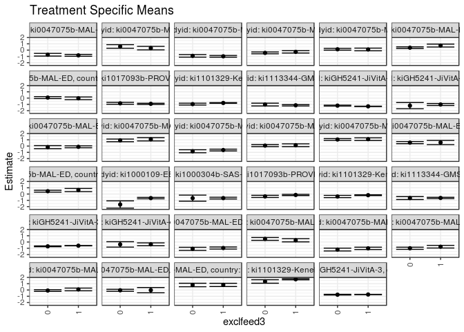

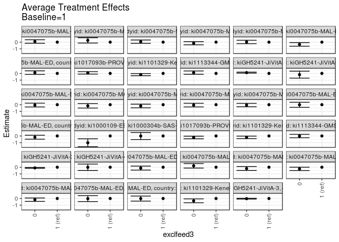

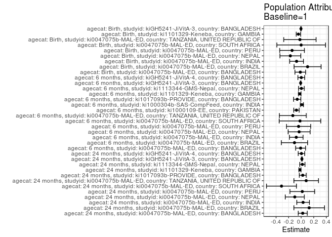

## Results Table

### Parameter: TSM

| agecat | studyid | country | intervention_level | baseline_level | estimate | ci_lower | ci_upper |
| --- | --- | --- | --- | --- | --- | --- | --- |
| Birth | ki0047075b-MAL-ED | BANGLADESH | 1 | NA | -0.9565323 | -1.1235023 | -0.7895623 |
| Birth | ki0047075b-MAL-ED | BANGLADESH | 0 | NA | -1.0868320 | -1.3347096 | -0.8389545 |
| Birth | ki0047075b-MAL-ED | BRAZIL | 1 | NA | 0.2815842 | 0.0246797 | 0.5384887 |
| Birth | ki0047075b-MAL-ED | BRAZIL | 0 | NA | 0.4896783 | 0.2604965 | 0.7188601 |
| Birth | ki0047075b-MAL-ED | INDIA | 1 | NA | -1.0096768 | -1.1966268 | -0.8227269 |
| Birth | ki0047075b-MAL-ED | INDIA | 0 | NA | -1.2023330 | -1.4273090 | -0.9773571 |
| Birth | ki0047075b-MAL-ED | NEPAL | 1 | NA | -0.7462967 | -0.9545985 | -0.5379949 |
| Birth | ki0047075b-MAL-ED | NEPAL | 0 | NA | -0.9945627 | -1.1659302 | -0.8231952 |
| Birth | ki0047075b-MAL-ED | PERU | 1 | NA | 0.0886281 | -0.1281553 | 0.3054115 |
| Birth | ki0047075b-MAL-ED | PERU | 0 | NA | -0.0880021 | -0.2219495 | 0.0459452 |
| Birth | ki0047075b-MAL-ED | SOUTH AFRICA | 1 | NA | -0.0288625 | -0.4453892 | 0.3876641 |
| Birth | ki0047075b-MAL-ED | SOUTH AFRICA | 0 | NA | -0.0483191 | -0.2074137 | 0.1107756 |
| Birth | ki0047075b-MAL-ED | TANZANIA, UNITED REPUBLIC OF | 1 | NA | 0.8066650 | 0.5502682 | 1.0630617 |
| Birth | ki0047075b-MAL-ED | TANZANIA, UNITED REPUBLIC OF | 0 | NA | 0.7948620 | 0.5184175 | 1.0713065 |
| Birth | ki1101329-Keneba | GAMBIA | 1 | NA | 1.7082548 | 1.6185769 | 1.7979326 |
| Birth | ki1101329-Keneba | GAMBIA | 0 | NA | 1.3560459 | 1.0775830 | 1.6345088 |
| Birth | kiGH5241-JiVitA-3 | BANGLADESH | 1 | NA | -0.7194824 | -0.7402145 | -0.6987503 |
| Birth | kiGH5241-JiVitA-3 | BANGLADESH | 0 | NA | -0.7489183 | -0.8068493 | -0.6909874 |
| 6 months | ki0047075b-MAL-ED | BANGLADESH | 1 | NA | -0.1160694 | -0.2703729 | 0.0382341 |
| 6 months | ki0047075b-MAL-ED | BANGLADESH | 0 | NA | -0.1706113 | -0.4130103 | 0.0717877 |
| 6 months | ki0047075b-MAL-ED | BRAZIL | 1 | NA | 1.0780875 | 0.8152906 | 1.3408843 |
| 6 months | ki0047075b-MAL-ED | BRAZIL | 0 | NA | 0.9075290 | 0.6950029 | 1.1200550 |
| 6 months | ki0047075b-MAL-ED | INDIA | 1 | NA | -0.6327252 | -0.7730876 | -0.4923628 |
| 6 months | ki0047075b-MAL-ED | INDIA | 0 | NA | -0.8259988 | -1.0640402 | -0.5879573 |
| 6 months | ki0047075b-MAL-ED | NEPAL | 1 | NA | 0.1333953 | -0.0895180 | 0.3563085 |
| 6 months | ki0047075b-MAL-ED | NEPAL | 0 | NA | 0.0747775 | -0.0894099 | 0.2389650 |
| 6 months | ki0047075b-MAL-ED | PERU | 1 | NA | 1.0979139 | 0.8861777 | 1.3096501 |
| 6 months | ki0047075b-MAL-ED | PERU | 0 | NA | 1.0436010 | 0.8969653 | 1.1902366 |
| 6 months | ki0047075b-MAL-ED | SOUTH AFRICA | 1 | NA | 0.5619489 | 0.2265975 | 0.8973003 |
| 6 months | ki0047075b-MAL-ED | SOUTH AFRICA | 0 | NA | 0.5497347 | 0.3796354 | 0.7198341 |
| 6 months | ki0047075b-MAL-ED | TANZANIA, UNITED REPUBLIC OF | 1 | NA | 0.6393141 | 0.3860706 | 0.8925577 |
| 6 months | ki0047075b-MAL-ED | TANZANIA, UNITED REPUBLIC OF | 0 | NA | 0.4500029 | 0.2961829 | 0.6038230 |
| 6 months | ki1000109-EE | PAKISTAN | 1 | NA | -0.6469130 | -0.7615182 | -0.5323078 |
| 6 months | ki1000109-EE | PAKISTAN | 0 | NA | -1.6645926 | -2.2440230 | -1.0851622 |
| 6 months | ki1000304b-SAS-CompFeed | INDIA | 1 | NA | -0.6465859 | -0.7848454 | -0.5083265 |
| 6 months | ki1000304b-SAS-CompFeed | INDIA | 0 | NA | -0.6556227 | -1.1386877 | -0.1725576 |
| 6 months | ki1017093b-PROVIDE | BANGLADESH | 1 | NA | -0.1457043 | -0.2421742 | -0.0492343 |
| 6 months | ki1017093b-PROVIDE | BANGLADESH | 0 | NA | -0.3769795 | -0.5482650 | -0.2056940 |
| 6 months | ki1101329-Keneba | GAMBIA | 1 | NA | -0.1833047 | -0.2416893 | -0.1249200 |
| 6 months | ki1101329-Keneba | GAMBIA | 0 | NA | -0.3922768 | -0.5688567 | -0.2156970 |
| 6 months | ki1113344-GMS-Nepal | NEPAL | 1 | NA | -0.6234819 | -0.7312709 | -0.5156929 |
| 6 months | ki1113344-GMS-Nepal | NEPAL | 0 | NA | -0.6381700 | -0.8737839 | -0.4025561 |
| 6 months | kiGH5241-JiVitA-3 | BANGLADESH | 1 | NA | -0.5852040 | -0.6060058 | -0.5644023 |
| 6 months | kiGH5241-JiVitA-3 | BANGLADESH | 0 | NA | -0.6876052 | -0.7493041 | -0.6259063 |
| 6 months | kiGH5241-JiVitA-4 | BANGLADESH | 1 | NA | -0.3679590 | -0.5956397 | -0.1402784 |
| 6 months | kiGH5241-JiVitA-4 | BANGLADESH | 0 | NA | -0.3800326 | -0.8070769 | 0.0470116 |
| 24 months | ki0047075b-MAL-ED | BANGLADESH | 1 | NA | -0.8331061 | -0.9824669 | -0.6837452 |
| 24 months | ki0047075b-MAL-ED | BANGLADESH | 0 | NA | -0.7346019 | -0.9481676 | -0.5210363 |
| 24 months | ki0047075b-MAL-ED | BRAZIL | 1 | NA | 0.3193075 | 0.0410897 | 0.5975253 |
| 24 months | ki0047075b-MAL-ED | BRAZIL | 0 | NA | 0.5833839 | 0.2985545 | 0.8682133 |
| 24 months | ki0047075b-MAL-ED | INDIA | 1 | NA | -0.9862090 | -1.1255809 | -0.8468371 |
| 24 months | ki0047075b-MAL-ED | INDIA | 0 | NA | -0.9156681 | -1.1193697 | -0.7119665 |
| 24 months | ki0047075b-MAL-ED | NEPAL | 1 | NA | -0.2781945 | -0.4638953 | -0.0924937 |
| 24 months | ki0047075b-MAL-ED | NEPAL | 0 | NA | -0.4395446 | -0.5846920 | -0.2943971 |
| 24 months | ki0047075b-MAL-ED | PERU | 1 | NA | 0.1060726 | -0.1065917 | 0.3187369 |
| 24 months | ki0047075b-MAL-ED | PERU | 0 | NA | 0.1338746 | -0.0081267 | 0.2758759 |
| 24 months | ki0047075b-MAL-ED | SOUTH AFRICA | 1 | NA | 0.7284020 | 0.4962643 | 0.9605397 |
| 24 months | ki0047075b-MAL-ED | SOUTH AFRICA | 0 | NA | 0.3886388 | 0.2563046 | 0.5209731 |
| 24 months | ki0047075b-MAL-ED | TANZANIA, UNITED REPUBLIC OF | 1 | NA | -0.0364354 | -0.2533816 | 0.1805107 |
| 24 months | ki0047075b-MAL-ED | TANZANIA, UNITED REPUBLIC OF | 0 | NA | 0.0814572 | -0.0728102 | 0.2357247 |
| 24 months | ki1017093b-PROVIDE | BANGLADESH | 1 | NA | -0.9129751 | -1.0106100 | -0.8153401 |
| 24 months | ki1017093b-PROVIDE | BANGLADESH | 0 | NA | -0.8339870 | -0.9864663 | -0.6815077 |
| 24 months | ki1101329-Keneba | GAMBIA | 1 | NA | -0.7746159 | -0.8289108 | -0.7203210 |
| 24 months | ki1101329-Keneba | GAMBIA | 0 | NA | -0.9603210 | -1.1116238 | -0.8090182 |
| 24 months | ki1113344-GMS-Nepal | NEPAL | 1 | NA | -1.1462020 | -1.2564842 | -1.0359199 |
| 24 months | ki1113344-GMS-Nepal | NEPAL | 0 | NA | -1.0301793 | -1.2546197 | -0.8057388 |
| 24 months | kiGH5241-JiVitA-3 | BANGLADESH | 1 | NA | -1.3153605 | -1.3406147 | -1.2901063 |
| 24 months | kiGH5241-JiVitA-3 | BANGLADESH | 0 | NA | -1.1981274 | -1.2724550 | -1.1237999 |
| 24 months | kiGH5241-JiVitA-4 | BANGLADESH | 1 | NA | -1.0181918 | -1.1795641 | -0.8568195 |
| 24 months | kiGH5241-JiVitA-4 | BANGLADESH | 0 | NA | -1.2046134 | -1.6986706 | -0.7105562 |

### Parameter: E(Y)

| agecat | studyid | country | intervention_level | baseline_level | estimate | ci_lower | ci_upper |
| --- | --- | --- | --- | --- | --- | --- | --- |
| Birth | ki0047075b-MAL-ED | BANGLADESH | NA | NA | -0.9701762 | -1.1093516 | -0.8310008 |
| Birth | ki0047075b-MAL-ED | BRAZIL | NA | NA | 0.3837288 | 0.2059602 | 0.5614974 |
| Birth | ki0047075b-MAL-ED | INDIA | NA | NA | -1.0824352 | -1.2259825 | -0.9388879 |
| Birth | ki0047075b-MAL-ED | NEPAL | NA | NA | -0.9184337 | -1.0582074 | -0.7786600 |
| Birth | ki0047075b-MAL-ED | PERU | NA | NA | -0.0558491 | -0.1687562 | 0.0570581 |
| Birth | ki0047075b-MAL-ED | SOUTH AFRICA | NA | NA | -0.0290476 | -0.1772448 | 0.1191495 |
| Birth | ki0047075b-MAL-ED | TANZANIA, UNITED REPUBLIC OF | NA | NA | 0.7865789 | 0.5832028 | 0.9899551 |
| Birth | ki1101329-Keneba | GAMBIA | NA | NA | 1.6646743 | 1.5791251 | 1.7502236 |
| Birth | kiGH5241-JiVitA-3 | BANGLADESH | NA | NA | -0.7222456 | -0.7423351 | -0.7021562 |
| 6 months | ki0047075b-MAL-ED | BANGLADESH | NA | NA | -0.1245816 | -0.2544517 | 0.0052886 |
| 6 months | ki0047075b-MAL-ED | BRAZIL | NA | NA | 0.9717225 | 0.8073791 | 1.1360658 |
| 6 months | ki0047075b-MAL-ED | INDIA | NA | NA | -0.7105222 | -0.8368775 | -0.5841669 |
| 6 months | ki0047075b-MAL-ED | NEPAL | NA | NA | 0.1010587 | -0.0308005 | 0.2329178 |
| 6 months | ki0047075b-MAL-ED | PERU | NA | NA | 1.0571296 | 0.9346064 | 1.1796528 |
| 6 months | ki0047075b-MAL-ED | SOUTH AFRICA | NA | NA | 0.5435551 | 0.3895443 | 0.6975659 |
| 6 months | ki0047075b-MAL-ED | TANZANIA, UNITED REPUBLIC OF | NA | NA | 0.5063403 | 0.3745918 | 0.6380888 |
| 6 months | ki1000109-EE | PAKISTAN | NA | NA | -0.7218667 | -0.8355727 | -0.6081607 |
| 6 months | ki1000304b-SAS-CompFeed | INDIA | NA | NA | -0.6348861 | -0.7630511 | -0.5067211 |
| 6 months | ki1017093b-PROVIDE | BANGLADESH | NA | NA | -0.2083706 | -0.2927992 | -0.1239419 |
| 6 months | ki1101329-Keneba | GAMBIA | NA | NA | -0.2057405 | -0.2614576 | -0.1500234 |
| 6 months | ki1113344-GMS-Nepal | NEPAL | NA | NA | -0.6194068 | -0.7173394 | -0.5214742 |
| 6 months | kiGH5241-JiVitA-3 | BANGLADESH | NA | NA | -0.5929896 | -0.6128338 | -0.5731455 |
| 6 months | kiGH5241-JiVitA-4 | BANGLADESH | NA | NA | -0.3657303 | -0.5647992 | -0.1666615 |
| 24 months | ki0047075b-MAL-ED | BANGLADESH | NA | NA | -0.8080769 | -0.9302432 | -0.6859106 |
| 24 months | ki0047075b-MAL-ED | BRAZIL | NA | NA | 0.4466272 | 0.2416144 | 0.6516401 |
| 24 months | ki0047075b-MAL-ED | INDIA | NA | NA | -0.9551111 | -1.0714034 | -0.8388188 |
| 24 months | ki0047075b-MAL-ED | NEPAL | NA | NA | -0.3795556 | -0.4938120 | -0.2652991 |
| 24 months | ki0047075b-MAL-ED | PERU | NA | NA | 0.1242714 | 0.0054301 | 0.2431126 |
| 24 months | ki0047075b-MAL-ED | SOUTH AFRICA | NA | NA | 0.4157543 | 0.2953789 | 0.5361297 |
| 24 months | ki0047075b-MAL-ED | TANZANIA, UNITED REPUBLIC OF | NA | NA | 0.0434286 | -0.0830724 | 0.1699295 |
| 24 months | ki1017093b-PROVIDE | BANGLADESH | NA | NA | -0.8879412 | -0.9708680 | -0.8050144 |
| 24 months | ki1101329-Keneba | GAMBIA | NA | NA | -0.7930925 | -0.8442611 | -0.7419240 |
| 24 months | ki1113344-GMS-Nepal | NEPAL | NA | NA | -1.1267450 | -1.2257791 | -1.0277110 |
| 24 months | kiGH5241-JiVitA-3 | BANGLADESH | NA | NA | -1.3031012 | -1.3269655 | -1.2792368 |
| 24 months | kiGH5241-JiVitA-4 | BANGLADESH | NA | NA | -1.0137086 | -1.1659964 | -0.8614208 |

### Parameter: ATE

| agecat | studyid | country | intervention_level | baseline_level | estimate | ci_lower | ci_upper |
| --- | --- | --- | --- | --- | --- | --- | --- |
| Birth | ki0047075b-MAL-ED | BANGLADESH | 1 | 1 | 0.0000000 | 0.0000000 | 0.0000000 |
| Birth | ki0047075b-MAL-ED | BANGLADESH | 0 | 1 | -0.1302997 | -0.4296726 | 0.1690732 |
| Birth | ki0047075b-MAL-ED | BRAZIL | 1 | 1 | 0.0000000 | 0.0000000 | 0.0000000 |
| Birth | ki0047075b-MAL-ED | BRAZIL | 0 | 1 | 0.2080941 | -0.1285178 | 0.5447060 |
| Birth | ki0047075b-MAL-ED | INDIA | 1 | 1 | 0.0000000 | 0.0000000 | 0.0000000 |
| Birth | ki0047075b-MAL-ED | INDIA | 0 | 1 | -0.1926562 | -0.4863200 | 0.1010076 |
| Birth | ki0047075b-MAL-ED | NEPAL | 1 | 1 | 0.0000000 | 0.0000000 | 0.0000000 |
| Birth | ki0047075b-MAL-ED | NEPAL | 0 | 1 | -0.2482660 | -0.5035712 | 0.0070391 |
| Birth | ki0047075b-MAL-ED | PERU | 1 | 1 | 0.0000000 | 0.0000000 | 0.0000000 |
| Birth | ki0047075b-MAL-ED | PERU | 0 | 1 | -0.1766303 | -0.4331216 | 0.0798611 |
| Birth | ki0047075b-MAL-ED | SOUTH AFRICA | 1 | 1 | 0.0000000 | 0.0000000 | 0.0000000 |
| Birth | ki0047075b-MAL-ED | SOUTH AFRICA | 0 | 1 | -0.0194565 | -0.4642157 | 0.4253026 |
| Birth | ki0047075b-MAL-ED | TANZANIA, UNITED REPUBLIC OF | 1 | 1 | 0.0000000 | 0.0000000 | 0.0000000 |
| Birth | ki0047075b-MAL-ED | TANZANIA, UNITED REPUBLIC OF | 0 | 1 | -0.0118029 | -0.3865812 | 0.3629753 |
| Birth | ki1101329-Keneba | GAMBIA | 1 | 1 | 0.0000000 | 0.0000000 | 0.0000000 |
| Birth | ki1101329-Keneba | GAMBIA | 0 | 1 | -0.3522089 | -0.6447879 | -0.0596299 |
| Birth | kiGH5241-JiVitA-3 | BANGLADESH | 1 | 1 | 0.0000000 | 0.0000000 | 0.0000000 |
| Birth | kiGH5241-JiVitA-3 | BANGLADESH | 0 | 1 | -0.0294359 | -0.0884312 | 0.0295593 |
| 6 months | ki0047075b-MAL-ED | BANGLADESH | 1 | 1 | 0.0000000 | 0.0000000 | 0.0000000 |
| 6 months | ki0047075b-MAL-ED | BANGLADESH | 0 | 1 | -0.0545419 | -0.3422951 | 0.2332114 |
| 6 months | ki0047075b-MAL-ED | BRAZIL | 1 | 1 | 0.0000000 | 0.0000000 | 0.0000000 |
| 6 months | ki0047075b-MAL-ED | BRAZIL | 0 | 1 | -0.1705585 | -0.5084479 | 0.1673309 |
| 6 months | ki0047075b-MAL-ED | INDIA | 1 | 1 | 0.0000000 | 0.0000000 | 0.0000000 |
| 6 months | ki0047075b-MAL-ED | INDIA | 0 | 1 | -0.1932736 | -0.4698369 | 0.0832897 |
| 6 months | ki0047075b-MAL-ED | NEPAL | 1 | 1 | 0.0000000 | 0.0000000 | 0.0000000 |
| 6 months | ki0047075b-MAL-ED | NEPAL | 0 | 1 | -0.0586177 | -0.3359076 | 0.2186722 |
| 6 months | ki0047075b-MAL-ED | PERU | 1 | 1 | 0.0000000 | 0.0000000 | 0.0000000 |
| 6 months | ki0047075b-MAL-ED | PERU | 0 | 1 | -0.0543130 | -0.3097478 | 0.2011219 |
| 6 months | ki0047075b-MAL-ED | SOUTH AFRICA | 1 | 1 | 0.0000000 | 0.0000000 | 0.0000000 |
| 6 months | ki0047075b-MAL-ED | SOUTH AFRICA | 0 | 1 | -0.0122142 | -0.3884519 | 0.3640236 |
| 6 months | ki0047075b-MAL-ED | TANZANIA, UNITED REPUBLIC OF | 1 | 1 | 0.0000000 | 0.0000000 | 0.0000000 |
| 6 months | ki0047075b-MAL-ED | TANZANIA, UNITED REPUBLIC OF | 0 | 1 | -0.1893112 | -0.4861336 | 0.1075112 |
| 6 months | ki1000109-EE | PAKISTAN | 1 | 1 | 0.0000000 | 0.0000000 | 0.0000000 |
| 6 months | ki1000109-EE | PAKISTAN | 0 | 1 | -1.0176796 | -1.6072858 | -0.4280734 |
| 6 months | ki1000304b-SAS-CompFeed | INDIA | 1 | 1 | 0.0000000 | 0.0000000 | 0.0000000 |
| 6 months | ki1000304b-SAS-CompFeed | INDIA | 0 | 1 | -0.0090367 | -0.5362411 | 0.5181676 |
| 6 months | ki1017093b-PROVIDE | BANGLADESH | 1 | 1 | 0.0000000 | 0.0000000 | 0.0000000 |
| 6 months | ki1017093b-PROVIDE | BANGLADESH | 0 | 1 | -0.2312752 | -0.4277085 | -0.0348419 |
| 6 months | ki1101329-Keneba | GAMBIA | 1 | 1 | 0.0000000 | 0.0000000 | 0.0000000 |
| 6 months | ki1101329-Keneba | GAMBIA | 0 | 1 | -0.2089722 | -0.3941027 | -0.0238416 |
| 6 months | ki1113344-GMS-Nepal | NEPAL | 1 | 1 | 0.0000000 | 0.0000000 | 0.0000000 |
| 6 months | ki1113344-GMS-Nepal | NEPAL | 0 | 1 | -0.0146881 | -0.2739173 | 0.2445412 |
| 6 months | kiGH5241-JiVitA-3 | BANGLADESH | 1 | 1 | 0.0000000 | 0.0000000 | 0.0000000 |
| 6 months | kiGH5241-JiVitA-3 | BANGLADESH | 0 | 1 | -0.1024012 | -0.1668082 | -0.0379941 |
| 6 months | kiGH5241-JiVitA-4 | BANGLADESH | 1 | 1 | 0.0000000 | 0.0000000 | 0.0000000 |
| 6 months | kiGH5241-JiVitA-4 | BANGLADESH | 0 | 1 | -0.0120736 | -0.4980740 | 0.4739268 |
| 24 months | ki0047075b-MAL-ED | BANGLADESH | 1 | 1 | 0.0000000 | 0.0000000 | 0.0000000 |
| 24 months | ki0047075b-MAL-ED | BANGLADESH | 0 | 1 | 0.0985041 | -0.1617871 | 0.3587953 |
| 24 months | ki0047075b-MAL-ED | BRAZIL | 1 | 1 | 0.0000000 | 0.0000000 | 0.0000000 |
| 24 months | ki0047075b-MAL-ED | BRAZIL | 0 | 1 | 0.2640764 | -0.1363851 | 0.6645378 |
| 24 months | ki0047075b-MAL-ED | INDIA | 1 | 1 | 0.0000000 | 0.0000000 | 0.0000000 |
| 24 months | ki0047075b-MAL-ED | INDIA | 0 | 1 | 0.0705410 | -0.1767046 | 0.3177865 |
| 24 months | ki0047075b-MAL-ED | NEPAL | 1 | 1 | 0.0000000 | 0.0000000 | 0.0000000 |
| 24 months | ki0047075b-MAL-ED | NEPAL | 0 | 1 | -0.1613500 | -0.3970823 | 0.0743822 |
| 24 months | ki0047075b-MAL-ED | PERU | 1 | 1 | 0.0000000 | 0.0000000 | 0.0000000 |
| 24 months | ki0047075b-MAL-ED | PERU | 0 | 1 | 0.0278020 | -0.2284277 | 0.2840317 |
| 24 months | ki0047075b-MAL-ED | SOUTH AFRICA | 1 | 1 | 0.0000000 | 0.0000000 | 0.0000000 |
| 24 months | ki0047075b-MAL-ED | SOUTH AFRICA | 0 | 1 | -0.3397632 | -0.6079229 | -0.0716034 |
| 24 months | ki0047075b-MAL-ED | TANZANIA, UNITED REPUBLIC OF | 1 | 1 | 0.0000000 | 0.0000000 | 0.0000000 |
| 24 months | ki0047075b-MAL-ED | TANZANIA, UNITED REPUBLIC OF | 0 | 1 | 0.1178927 | -0.1488354 | 0.3846208 |
| 24 months | ki1017093b-PROVIDE | BANGLADESH | 1 | 1 | 0.0000000 | 0.0000000 | 0.0000000 |
| 24 months | ki1017093b-PROVIDE | BANGLADESH | 0 | 1 | 0.0789881 | -0.1015340 | 0.2595102 |
| 24 months | ki1101329-Keneba | GAMBIA | 1 | 1 | 0.0000000 | 0.0000000 | 0.0000000 |
| 24 months | ki1101329-Keneba | GAMBIA | 0 | 1 | -0.1857051 | -0.3464746 | -0.0249356 |
| 24 months | ki1113344-GMS-Nepal | NEPAL | 1 | 1 | 0.0000000 | 0.0000000 | 0.0000000 |
| 24 months | ki1113344-GMS-Nepal | NEPAL | 0 | 1 | 0.1160227 | -0.1342832 | 0.3663287 |
| 24 months | kiGH5241-JiVitA-3 | BANGLADESH | 1 | 1 | 0.0000000 | 0.0000000 | 0.0000000 |
| 24 months | kiGH5241-JiVitA-3 | BANGLADESH | 0 | 1 | 0.1172331 | 0.0386501 | 0.1958161 |
| 24 months | kiGH5241-JiVitA-4 | BANGLADESH | 1 | 1 | 0.0000000 | 0.0000000 | 0.0000000 |
| 24 months | kiGH5241-JiVitA-4 | BANGLADESH | 0 | 1 | -0.1864216 | -0.7079686 | 0.3351254 |

### Parameter: PAR

| agecat | studyid | country | intervention_level | baseline_level | estimate | ci_lower | ci_upper |
| --- | --- | --- | --- | --- | --- | --- | --- |
| Birth | ki0047075b-MAL-ED | BANGLADESH | 1 | NA | -0.0136439 | -0.0984911 | 0.0712033 |
| Birth | ki0047075b-MAL-ED | BRAZIL | 1 | NA | 0.1021446 | -0.1124281 | 0.3167173 |
| Birth | ki0047075b-MAL-ED | INDIA | 1 | NA | -0.0727584 | -0.1826203 | 0.0371035 |
| Birth | ki0047075b-MAL-ED | NEPAL | 1 | NA | -0.1721370 | -0.3381751 | -0.0060990 |
| Birth | ki0047075b-MAL-ED | PERU | 1 | NA | -0.1444772 | -0.3407065 | 0.0517522 |
| Birth | ki0047075b-MAL-ED | SOUTH AFRICA | 1 | NA | -0.0001851 | -0.3867464 | 0.3863762 |
| Birth | ki0047075b-MAL-ED | TANZANIA, UNITED REPUBLIC OF | 1 | NA | -0.0200860 | -0.2768698 | 0.2366978 |
| Birth | ki1101329-Keneba | GAMBIA | 1 | NA | -0.0435804 | -0.0786179 | -0.0085430 |
| Birth | kiGH5241-JiVitA-3 | BANGLADESH | 1 | NA | -0.0027632 | -0.0081972 | 0.0026707 |
| 6 months | ki0047075b-MAL-ED | BANGLADESH | 1 | NA | -0.0085122 | -0.0873967 | 0.0703724 |
| 6 months | ki0047075b-MAL-ED | BRAZIL | 1 | NA | -0.1063650 | -0.3154005 | 0.1026706 |
| 6 months | ki0047075b-MAL-ED | INDIA | 1 | NA | -0.0777970 | -0.1863960 | 0.0308021 |
| 6 months | ki0047075b-MAL-ED | NEPAL | 1 | NA | -0.0323366 | -0.2071972 | 0.1425240 |
| 6 months | ki0047075b-MAL-ED | PERU | 1 | NA | -0.0407843 | -0.2332476 | 0.1516790 |
| 6 months | ki0047075b-MAL-ED | SOUTH AFRICA | 1 | NA | -0.0183938 | -0.3493240 | 0.3125364 |
| 6 months | ki0047075b-MAL-ED | TANZANIA, UNITED REPUBLIC OF | 1 | NA | -0.1329739 | -0.3464973 | 0.0805496 |
| 6 months | ki1000109-EE | PAKISTAN | 1 | NA | -0.0749536 | -0.1180927 | -0.0318146 |
| 6 months | ki1000304b-SAS-CompFeed | INDIA | 1 | NA | 0.0116999 | -0.0141795 | 0.0375792 |
| 6 months | ki1017093b-PROVIDE | BANGLADESH | 1 | NA | -0.0626663 | -0.1200454 | -0.0052872 |
| 6 months | ki1101329-Keneba | GAMBIA | 1 | NA | -0.0224359 | -0.0435178 | -0.0013539 |
| 6 months | ki1113344-GMS-Nepal | NEPAL | 1 | NA | 0.0040751 | -0.0405996 | 0.0487498 |
| 6 months | kiGH5241-JiVitA-3 | BANGLADESH | 1 | NA | -0.0077856 | -0.0135829 | -0.0019883 |
| 6 months | kiGH5241-JiVitA-4 | BANGLADESH | 1 | NA | 0.0022287 | -0.0513188 | 0.0557762 |
| 24 months | ki0047075b-MAL-ED | BANGLADESH | 1 | NA | 0.0250292 | -0.0467263 | 0.0967846 |
| 24 months | ki0047075b-MAL-ED | BRAZIL | 1 | NA | 0.1273197 | -0.1157798 | 0.3704192 |
| 24 months | ki0047075b-MAL-ED | INDIA | 1 | NA | 0.0310979 | -0.0696184 | 0.1318142 |
| 24 months | ki0047075b-MAL-ED | NEPAL | 1 | NA | -0.1013611 | -0.2526971 | 0.0499749 |
| 24 months | ki0047075b-MAL-ED | PERU | 1 | NA | 0.0181987 | -0.1785182 | 0.2149157 |
| 24 months | ki0047075b-MAL-ED | SOUTH AFRICA | 1 | NA | -0.3126477 | -0.5508233 | -0.0744721 |
| 24 months | ki0047075b-MAL-ED | TANZANIA, UNITED REPUBLIC OF | 1 | NA | 0.0798640 | -0.1153343 | 0.2750623 |
| 24 months | ki1017093b-PROVIDE | BANGLADESH | 1 | NA | 0.0250339 | -0.0298096 | 0.0798774 |
| 24 months | ki1101329-Keneba | GAMBIA | 1 | NA | -0.0184767 | -0.0353074 | -0.0016460 |
| 24 months | ki1113344-GMS-Nepal | NEPAL | 1 | NA | 0.0194570 | -0.0225555 | 0.0614694 |
| 24 months | kiGH5241-JiVitA-3 | BANGLADESH | 1 | NA | 0.0122593 | 0.0046267 | 0.0198920 |
| 24 months | kiGH5241-JiVitA-4 | BANGLADESH | 1 | NA | 0.0044832 | -0.0471702 | 0.0561366 |